# Milestone1_EDA_added(Group7)

## CAPSTONE PROJECT INTERIM REPORT(With EDA) - Group: 007, Batch: AUG 22A

### Project: COMPUTER VISION - 2 (OBJECT DETECTION – CAR)

### Project Objective: Design a DL-Based Car Identification Model

**Milestone 1(With EDA):**

```python
# Google colab pro to increase RAM
from psutil import virtual_memory
ram_gb = virtual_memory().total / 1e9
print('Your runtime has {:.1f} gigabytes of available RAM\n'.format(ram_gb))

if ram_gb < 20:
  print('Not using a high-RAM runtime')
else:
  print('You are using a high-RAM runtime!')
```

```
Your runtime has 54.8 gigabytes of available RAM

You are using a high-RAM runtime!
```

#### Import Libraries

```python
import pandas as pd
import numpy as np
from PIL import Image     # PIL for image manipulation
import os
import cv2
import matplotlib.pyplot as plt
import matplotlib.patches as patches
%matplotlib inline
import random
random.seed(0)
import warnings
warnings.filterwarnings("ignore")
import tensorflow
from tensorflow.keras.applications import MobileNetV2
from tensorflow.keras.applications.mobilenet import preprocess_input
from tensorflow.keras.models import model_from_json
from tensorflow.keras.layers import Flatten, Conv2D, Reshape, Dense, Dropout, BatchNormalization
from tensorflow.keras.models import Model
import keras
from keras.backend import sigmoid
```

```python
# Mounting the drive
from google.colab import drive
drive.mount('/content/drive')
```

#### Step 1: Import the data

```python
# Assigning the Google drive path
capstone_path = '/content/drive/My Drive/Capstone_project/'
```

```python
# Reading the csv files
classNamesData = pd.read_csv(capstone_path+"Car+names+and+make.csv", header=None, names=["class_name"])
trainAnnotate = pd.read_csv(capstone_path+"Annotations/Train Annotations.csv")
testAnnotate = pd.read_csv(capstone_path+"Annotations/Test Annotation.csv")
```

```python
# Rename the column names as per our convenience
trainAnnotate.rename(columns={'Image Name': 'image_file', 'Bounding Box coordinates': 'x0', 'Unnamed: 2':'y0','Unnamed: 3': 'x1','Unnamed: 4': 'y1', 'Image class':'class'}, inplace=True)
testAnnotate.rename(columns={'Image Name': 'image_file', 'Bounding Box coordinates': 'x0', 'Unnamed: 2':'y0','Unnamed: 3': 'x1','Unnamed: 4': 'y1', 'Image class':'class'}, inplace=True)
```

```python
# Head the ClassNameData
classNamesData.head()
```

|  | class_name |
| --- | --- |
| 0 | AM General Hummer SUV 2000 |
| 1 | Acura RL Sedan 2012 |
| 2 | Acura TL Sedan 2012 |
| 3 | Acura TL Type-S 2008 |
| 4 | Acura TSX Sedan 2012 |

```python
# Head the trainAnnotate
trainAnnotate.head()
```

|  | image_file | x0 | y0 | x1 | y1 | class |
| --- | --- | --- | --- | --- | --- | --- |
| 0 | 00001.jpg | 39 | 116 | 569 | 375 | 14 |
| 1 | 00002.jpg | 36 | 116 | 868 | 587 | 3 |
| 2 | 00003.jpg | 85 | 109 | 601 | 381 | 91 |
| 3 | 00004.jpg | 621 | 393 | 1484 | 1096 | 134 |
| 4 | 00005.jpg | 14 | 36 | 133 | 99 | 106 |

```python
# Head the testAnnotate
testAnnotate.head()
```

|  | image_file | x0 | y0 | x1 | y1 | class |
| --- | --- | --- | --- | --- | --- | --- |
| 0 | 00001.jpg | 30 | 52 | 246 | 147 | 181 |
| 1 | 00002.jpg | 100 | 19 | 576 | 203 | 103 |
| 2 | 00003.jpg | 51 | 105 | 968 | 659 | 145 |
| 3 | 00004.jpg | 67 | 84 | 581 | 407 | 187 |
| 4 | 00005.jpg | 140 | 151 | 593 | 339 | 185 |

#### Step 2: Map training and testing images to its classes

```python
# Defining the function to get image as a list
def get_image_list(image_path):
  train_image_dir = os.listdir(image_path)
  trainImageList=[]
  for i in train_image_dir:
    for f in os.listdir(os.path.join(image_path, i)):
        ext = os.path.splitext(f)[1]
        if ext == '.jpg' or ext == '.jpeg':
          trainImageList.append("{}/{}".format(i,f))
  return trainImageList
```

```python
# Defining the function to map images with classes
def map_image_metadata(image_base_path, annotate_metadata, image_path_list):
  image_path_lst_split = [i.split('/')[1] for i in image_path_list]
  annotate_metadata["car_image_path"] = annotate_metadata.apply(lambda row: image_base_path+'/'+ image_path_list[image_path_lst_split.index(row['image_file'])], axis=1)
  return annotate_metadata
```

```python
# Calling the function for mapping the training images
train_imagePath = capstone_path+"/Car Images/Train Images"
train_imageList = get_image_list(train_imagePath)
train_Annotate = map_image_metadata(train_imagePath, trainAnnotate, train_imageList)
```

```python
train_Annotate.head()
```

|  | image_file | x0 | y0 | x1 | y1 | class | car_image_path |
| --- | --- | --- | --- | --- | --- | --- | --- |
| 0 | 00001.jpg | 39 | 116 | 569 | 375 | 14 | /content/drive/My Drive/Capstone_project//Car ... |
| 1 | 00002.jpg | 36 | 116 | 868 | 587 | 3 | /content/drive/My Drive/Capstone_project//Car ... |
| 2 | 00003.jpg | 85 | 109 | 601 | 381 | 91 | /content/drive/My Drive/Capstone_project//Car ... |
| 3 | 00004.jpg | 621 | 393 | 1484 | 1096 | 134 | /content/drive/My Drive/Capstone_project//Car ... |
| 4 | 00005.jpg | 14 | 36 | 133 | 99 | 106 | /content/drive/My Drive/Capstone_project//Car ... |

```python
# Calling the function for mapping the testing images
test_imagePath = capstone_path+"/Car Images/Test Images"
test_imageList = get_image_list(test_imagePath)
test_Annotate = map_image_metadata(test_imagePath, testAnnotate, test_imageList)
```

```python
test_Annotate.head()
```

|  | image_file | x0 | y0 | x1 | y1 | class | car_image_path |
| --- | --- | --- | --- | --- | --- | --- | --- |
| 0 | 00001.jpg | 30 | 52 | 246 | 147 | 181 | /content/drive/My Drive/Capstone_project//Car ... |
| 1 | 00002.jpg | 100 | 19 | 576 | 203 | 103 | /content/drive/My Drive/Capstone_project//Car ... |
| 2 | 00003.jpg | 51 | 105 | 968 | 659 | 145 | /content/drive/My Drive/Capstone_project//Car ... |
| 3 | 00004.jpg | 67 | 84 | 581 | 407 | 187 | /content/drive/My Drive/Capstone_project//Car ... |
| 4 | 00005.jpg | 140 | 151 | 593 | 339 | 185 | /content/drive/My Drive/Capstone_project//Car ... |

#### Step 3: Map training and testing images to its annotations

```python
# Lambda function to create a column to map train images and its annotation
train_Annotate['class_name'] = train_Annotate.apply(lambda x: classNamesData['class_name'][(x['class']-1)], axis=1)
```

```python
train_Annotate.head()
```

|  | image_file | x0 | y0 | x1 | y1 | class | car_image_path | class_name |
| --- | --- | --- | --- | --- | --- | --- | --- | --- |
| 0 | 00001.jpg | 39 | 116 | 569 | 375 | 14 | /content/drive/My Drive/Capstone_project//Car ... | Audi TTS Coupe 2012 |
| 1 | 00002.jpg | 36 | 116 | 868 | 587 | 3 | /content/drive/My Drive/Capstone_project//Car ... | Acura TL Sedan 2012 |
| 2 | 00003.jpg | 85 | 109 | 601 | 381 | 91 | /content/drive/My Drive/Capstone_project//Car ... | Dodge Dakota Club Cab 2007 |
| 3 | 00004.jpg | 621 | 393 | 1484 | 1096 | 134 | /content/drive/My Drive/Capstone_project//Car ... | Hyundai Sonata Hybrid Sedan 2012 |
| 4 | 00005.jpg | 14 | 36 | 133 | 99 | 106 | /content/drive/My Drive/Capstone_project//Car ... | Ford F-450 Super Duty Crew Cab 2012 |

```python
# Lambda function to create a column to map test images and its annotation
test_Annotate['class_name'] = test_Annotate.apply(lambda x: classNamesData['class_name'][(x['class']-1)], axis=1)
```

```python
test_Annotate.head()
```

|  | image_file | x0 | y0 | x1 | y1 | class | car_image_path | class_name |
| --- | --- | --- | --- | --- | --- | --- | --- | --- |
| 0 | 00001.jpg | 30 | 52 | 246 | 147 | 181 | /content/drive/My Drive/Capstone_project//Car ... | Suzuki Aerio Sedan 2007 |
| 1 | 00002.jpg | 100 | 19 | 576 | 203 | 103 | /content/drive/My Drive/Capstone_project//Car ... | Ferrari 458 Italia Convertible 2012 |
| 2 | 00003.jpg | 51 | 105 | 968 | 659 | 145 | /content/drive/My Drive/Capstone_project//Car ... | Jeep Patriot SUV 2012 |
| 3 | 00004.jpg | 67 | 84 | 581 | 407 | 187 | /content/drive/My Drive/Capstone_project//Car ... | Toyota Camry Sedan 2012 |
| 4 | 00005.jpg | 140 | 151 | 593 | 339 | 185 | /content/drive/My Drive/Capstone_project//Car ... | Tesla Model S Sedan 2012 |

#### Step 4: Display images with bounding box

```python
# Creating a function to display the image
def display_image(image_path):
  img = cv2.imread(image_path,1)
  plt.imshow(img)
  plt.show()
```

```python
# Creating a function to display the boundingbox
def boundingbox_image(df):
  img = cv2.imread(df.car_image_path,1)
  x0=df.x0
  x1=df.x1
  y0=df.y0
  y1=df.y1

  fig, ax = plt.subplots(1)
  ax.imshow(img)
  rect = patches.Rectangle((x0,y0), (x1-x0),(y1-y0),linewidth=2.5, edgecolor='g', facecolor='none')
  ax.add_patch(rect)
  plt.title(df.class_name)
  plt.show()
```

[figure not shown]

```python
# Display a sample training image
df_train = train_Annotate.iloc[25]
display_image(df_train["car_image_path"])
```

[figure not shown]

```python
# Display a boundingbox for the same training image
boundingbox_image(df_train)
```

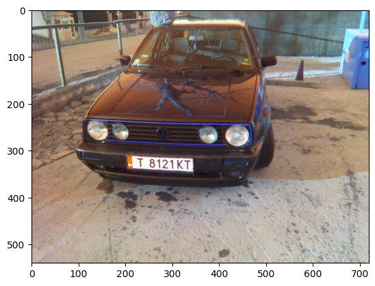

```python
# Display a sample testing image
df_test = test_Annotate.iloc[25]
display_image(df_test["car_image_path"])
```

[figure not shown]

```python
# Display a boundingbox for the same testing image
boundingbox_image(df_test)
```

# **EDA of Car Dataset (We received the comment from milestone 1 evaluator)**

```
EDA Visualizations for Train Image
```

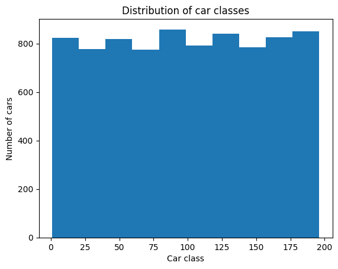

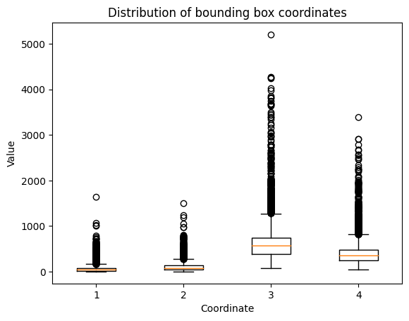

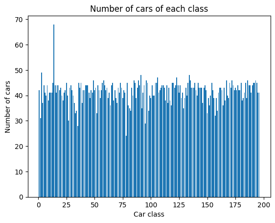

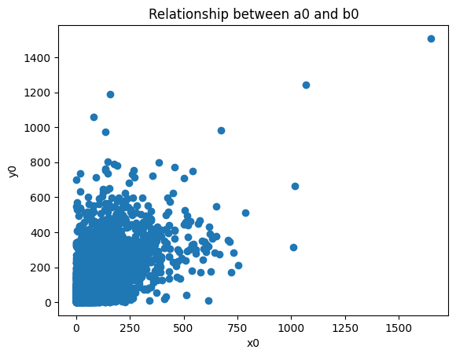

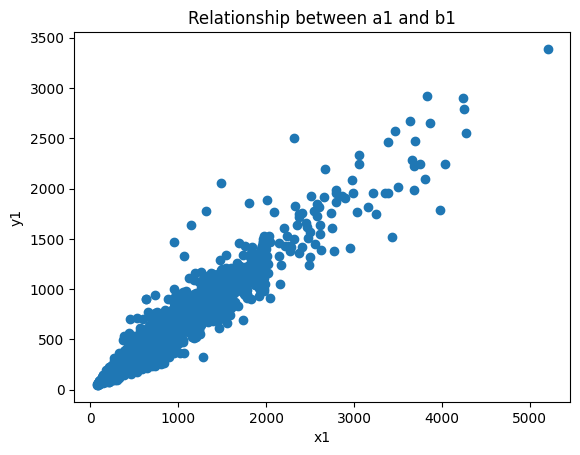

```
The most common car class is: 119
EDA Visualizations for Test Image
```

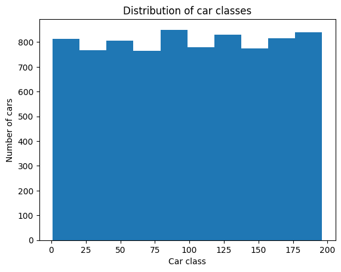

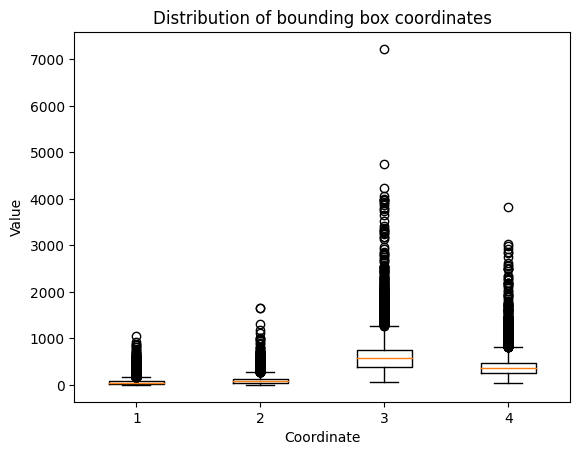

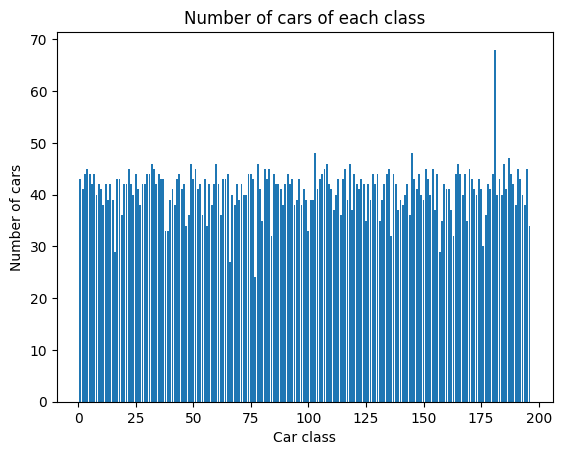

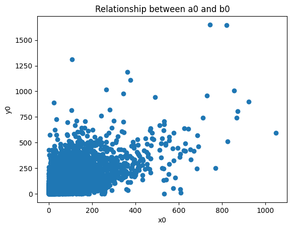

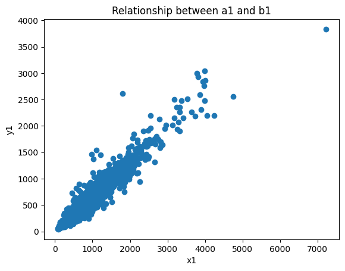

```
The most common car class is: 119
```

```python
import pandas as pd
import matplotlib.pyplot as plt
import seaborn as sns

def eda(df):

  ### Univariate analysis ###

  # Histogram of the class column
  plt.hist(df['class'])
  plt.xlabel('Car class')
  plt.ylabel('Number of cars')
  plt.title('Distribution of car classes')
  plt.show()

  # Box plot of the a0, b0, a1, and b1 columns
  plt.boxplot([df['x0'], df['y0'], df['x1'], df['y1']])
  plt.xlabel('Coordinate')
  plt.ylabel('Value')
  plt.title('Distribution of bounding box coordinates')
  plt.show()

  # Bar chart of the number of cars of each class
  plt.bar(df['class'].unique(), df['class'].value_counts())
  plt.xlabel('Car class')
  plt.ylabel('Number of cars')
  plt.title('Number of cars of each class')
  plt.show()

  ### Bivariate analysis ###

  # Scatter plot of the a0 and b0 columns
  plt.scatter(df['x0'], df['y0'])
  plt.xlabel('x0')
  plt.ylabel('y0')
  plt.title('Relationship between a0 and b0')
  plt.show()

  # Scatter plot of the a1 and b1 columns
  plt.scatter(df['x1'], df['y1'])
  plt.xlabel('x1')
  plt.ylabel('y1')
  plt.title('Relationship between a1 and b1')
  plt.show()

  # Insights
  print('The most common car class is:', df['class'].value_counts().sort_values(ascending=False).index[0])
print("EDA Visualizations for Train Image")
eda(train_Annotate)
print("EDA Visualizations for Test Image")
eda(test_Annotate)
```

#### Step 5: Design, train and test basic CNN models to classify the car

```python
# Resizing image size to avoid the RAM error
Image_Height = 224
Image_Width = 224
Height_Cells= 32
Width_Cells = 32
Image_Size = 224
Alpha = 1
```

```python
# Defining the function to resize all the images
def resize_image_data(annotate):
    resized_images = []
    images_boundingbox = []
    images_class = []

    for index, rows in annotate.iterrows():
        img = cv2.UMat(cv2.imread(rows['car_image_path'],1)).get()
        try:
          img_resized = cv2.resize(img,(Image_Width,Image_Height), interpolation = cv2.INTER_AREA)
          img_hw = np.zeros((4,1), dtype=np.float32)
          img_hw[0] = rows['x0']*Image_Width/img.shape[1]
          img_hw[1] = rows['y0']*Image_Height/img.shape[0]
          img_hw[2] = (rows['x1']-rows['x0'])*Image_Width/img.shape[1]
          img_hw[3] = (rows['y1']-rows['y0'])*Image_Height/img.shape[0]

          images_boundingbox.append(img_hw)
          resized_images.append(preprocess_input(np.array(img_resized, dtype=np.float32)))
          images_class.append(rows['class'])

          del img, img_resized, img_hw
        except:
          break

    return resized_images, images_boundingbox, images_class
```

```python
# Resizing the training images
#train_images, train_boundingbox, train_class = resize_image_data(train_Annotate)
```

```python
# Assigning the data path to save the resized images
data_path = "/content/drive/My Drive/Capstone_project/"
```

```python
# Save the resized train images in the data path

#np.save(data_path+"train_images.npy",train_images)
#np.save(data_path+"train_boundingbox.npy", train_boundingbox)
#np.save(data_path+"train_class.npy", train_class)
```

```python
# Load the saved train images
train_images = np.load(data_path+"train_images.npy")
train_boundingbox = np.load(data_path+"train_boundingbox.npy")
train_class = np.load(data_path+"train_class.npy")
```

```python
#test_images, test_boundingbox, test_class = resize_image_data(test_Annotate)
```

```python
# Save the resized test images in the data path

#np.save(data_path+"test_images.npy",test_images)
#np.save(data_path+"test_boundingbox.npy", test_boundingbox)
#np.save(data_path+"test_classes.npy", test_class)
```

```python
# Load the saved test images
test_images = np.load(data_path+"test_images.npy")
test_boundingbox = np.load(data_path+"test_boundingbox.npy")
test_class = np.load(data_path+"test_classes.npy")
```

Note: Due to the low RAM storage, We have saved the resized training and testing images in drive for future run.

```python
# Defining the function for swish activation based sigmoid function
def swish(x, beta = 1):
    return (x*sigmoid(beta*x))
```

```python
# Define the function for classification model
def create_classification_model(trainable=True):
    model = MobileNetV2(input_shape=(224,224,3), alpha=1.0, include_top=False, weights='imagenet',
            classifier_activation='softmax')

    for layer in model.layers:
        layer.trainable = trainable

    x=model.output
    x=Dropout(0.2)(x)
    x=BatchNormalization(epsilon=0.0001)(x)
    x=Flatten()(x)
    x=Dense(1024,activation='relu')(x)      # add dense layers - the model can learn more complex functions and classify for better results.
    x=Dropout(0.2)(x)
    x=BatchNormalization(epsilon=0.0001)(x)
    #x=Dense(1024,activation='swish')(x)    # dense layer 2
    x=Dense(512,activation='relu')(x)       # dense layer 3
    x=Dense(196,activation='softmax')(x)    # final layer with softmax activation

    return Model(inputs=model.input, outputs=x)
```

```python
# Define the function for predicting the bounding box to the given image
def generate_boundingbox_model(trainable=True):
    model = MobileNetV2(input_shape=(224,224,3), alpha=1.0, include_top=False, weights='imagenet',
            classifier_activation='softmax')

    for layer in model.layers:
        layer.trainable = trainable

    x0 = model.layers[-1].output
    x1 = Conv2D(4, kernel_size=7, name="coords")(x0)
    x2 = Reshape((4,))(x1)

    return Model(inputs=model.input, outputs=x2)
```

```python
# Define the function: IOU for evaluation metrics of bounding box

def IOU(y_true, y_pred):
    intersections = 0
    unions = 0

    # set the types so we are sure what type we are using
    gt = y_true
    pred = y_pred

    # Compute interection of predicted (pred) and ground truth (gt) bounding boxes
    diff_width = np.minimum(gt[:,0] + gt[:,2], pred[:,0] + pred[:,2]) - np.maximum(gt[:,0], pred[:,0])
    diff_height = np.minimum(gt[:,1] + gt[:,3], pred[:,1] + pred[:,3]) - np.maximum(gt[:,1], pred[:,1])
    intersection = diff_width * diff_height

    # Compute union
    area_gt = gt[:,2] * gt[:,3]
    area_pred = pred[:,2] * pred[:,3]
    union = area_gt + area_pred - intersection

    # Compute intersection and union over multiple boxes
    for j, _ in enumerate(union):
      if union[j] > 0 and intersection[j] > 0 and union[j] >= intersection[j]:
        intersections += intersection[j]
        unions += union[j]

    # Compute IOU. Use epsilon to prevent division by zero
    iou = np.round(intersections / (unions + tensorflow.keras.backend.epsilon()), 4)

    # This must match the type used in py_function
    iou = iou.astype(np.float32)

    return iou
```

```python
# Define the function to Get IoU value based on the provided and predicted bounding box
def IoU(y_true, y_pred):
    iou = tensorflow.py_function(IOU, [y_true, y_pred], Tout=tensorflow.float32)
    return iou
```

```python
# Generate the classification model
classification_model = create_classification_model(False)
classification_model.summary()
```

```
Model: "model"
__________________________________________________________________________________________________
 Layer (type)                   Output Shape         Param #     Connected to
==================================================================================================
 input_1 (InputLayer)           [(None, 224, 224, 3  0           []
                                )]

 Conv1 (Conv2D)                 (None, 112, 112, 32  864         ['input_1[0][0]']
                                )

 bn_Conv1 (BatchNormalization)  (None, 112, 112, 32  128         ['Conv1[0][0]']
                                )

 Conv1_relu (ReLU)              (None, 112, 112, 32  0           ['bn_Conv1[0][0]']
                                )

 expanded_conv_depthwise (Depth  (None, 112, 112, 32  288        ['Conv1_relu[0][0]']
 wiseConv2D)                    )

 expanded_conv_depthwise_BN (Ba  (None, 112, 112, 32  128        ['expanded_conv_depthwise[0][0]']
 tchNormalization)              )

 expanded_conv_depthwise_relu (  (None, 112, 112, 32  0          ['expanded_conv_depthwise_BN[0][0
 ReLU)                          )                                ]']

 expanded_conv_project (Conv2D)  (None, 112, 112, 16  512        ['expanded_conv_depthwise_relu[0]
                                )                                [0]']

 expanded_conv_project_BN (Batc  (None, 112, 112, 16  64         ['expanded_conv_project[0][0]']
 hNormalization)                )

 block_1_expand (Conv2D)        (None, 112, 112, 96  1536        ['expanded_conv_project_BN[0][0]'
                                )                                ]

 block_1_expand_BN (BatchNormal  (None, 112, 112, 96  384        ['block_1_expand[0][0]']
 ization)                       )

 block_1_expand_relu (ReLU)     (None, 112, 112, 96  0           ['block_1_expand_BN[0][0]']
                                )

```

[output cut: 366 more lines]

```

 dropout_1 (Dropout)            (None, 1024)         0           ['dense[0][0]']

 batch_normalization_1 (BatchNo  (None, 1024)        4096        ['dropout_1[0][0]']
 rmalization)

 dense_1 (Dense)                (None, 512)          524800      ['batch_normalization_1[0][0]']

 dense_2 (Dense)                (None, 196)          100548      ['dense_1[0][0]']

==================================================================================================
Total params: 67,118,852
Trainable params: 64,856,260
Non-trainable params: 2,262,592
__________________________________________________________________________________________________
```

```python
# Generate Bounding box model
boundingbox_model = generate_boundingbox_model(False)
boundingbox_model.summary()
```

```
Model: "model_1"
__________________________________________________________________________________________________
 Layer (type)                   Output Shape         Param #     Connected to
==================================================================================================
 input_2 (InputLayer)           [(None, 224, 224, 3  0           []
                                )]

 Conv1 (Conv2D)                 (None, 112, 112, 32  864         ['input_2[0][0]']
                                )

 bn_Conv1 (BatchNormalization)  (None, 112, 112, 32  128         ['Conv1[0][0]']
                                )

 Conv1_relu (ReLU)              (None, 112, 112, 32  0           ['bn_Conv1[0][0]']
                                )

 expanded_conv_depthwise (Depth  (None, 112, 112, 32  288        ['Conv1_relu[0][0]']
 wiseConv2D)                    )

 expanded_conv_depthwise_BN (Ba  (None, 112, 112, 32  128        ['expanded_conv_depthwise[0][0]']
 tchNormalization)              )

 expanded_conv_depthwise_relu (  (None, 112, 112, 32  0          ['expanded_conv_depthwise_BN[0][0
 ReLU)                          )                                ]']

 expanded_conv_project (Conv2D)  (None, 112, 112, 16  512        ['expanded_conv_depthwise_relu[0]
                                )                                [0]']

 expanded_conv_project_BN (Batc  (None, 112, 112, 16  64         ['expanded_conv_project[0][0]']
 hNormalization)                )

 block_1_expand (Conv2D)        (None, 112, 112, 96  1536        ['expanded_conv_project_BN[0][0]'
                                )                                ]

 block_1_expand_BN (BatchNormal  (None, 112, 112, 96  384        ['block_1_expand[0][0]']
 ization)                       )

 block_1_expand_relu (ReLU)     (None, 112, 112, 96  0           ['block_1_expand_BN[0][0]']
                                )

```

[output cut: 352 more lines]

```
 Conv_1 (Conv2D)                (None, 7, 7, 1280)   409600      ['block_16_project_BN[0][0]']

 Conv_1_bn (BatchNormalization)  (None, 7, 7, 1280)  5120        ['Conv_1[0][0]']

 out_relu (ReLU)                (None, 7, 7, 1280)   0           ['Conv_1_bn[0][0]']

 coords (Conv2D)                (None, 1, 1, 4)      250884      ['out_relu[0][0]']

 reshape (Reshape)              (None, 4)            0           ['coords[0][0]']

==================================================================================================
Total params: 2,508,868
Trainable params: 250,884
Non-trainable params: 2,257,984
__________________________________________________________________________________________________
```

```python
# Compile the model
boundingbox_model.compile(loss="mean_squared_error", optimizer="adam", metrics=[IoU])  # MSE - Regression error
```

```python
# Compile the models
classification_model.compile(loss="categorical_crossentropy", optimizer="adam", metrics="accuracy")
```

```python
# The images and bounding box after resizing is done
image_array = train_images[25]
PIL_image = Image.fromarray(np.uint8(image_array*255))
```

```python
x0 = train_boundingbox[10][0]
y0 = train_boundingbox[10][1]
wid = train_boundingbox[10][2]
hght = train_boundingbox[10][3]
print("{}   {}   {}  {}".format(x0,y0,wid,hght))
```

```
[17.85]   [49.132076]   [192.5]  [158.49057]
```

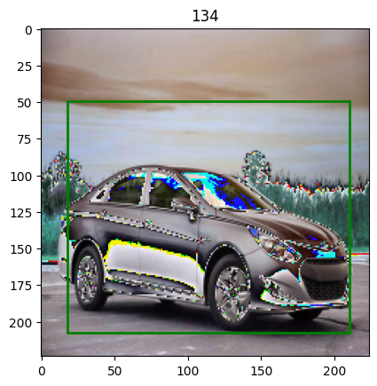

```python
fig, ax = plt.subplots(1)
ax.imshow(PIL_image)
rect = patches.Rectangle((x0,y0), wid, hght, linewidth=2, edgecolor='g', facecolor='none')
ax.add_patch(rect)
plt.title(train_class[25])
plt.show()
```

```python
# Generate one hot encoding for train classes
train_classDummy = pd.get_dummies(train_class)
train_classDummy.head()
```

|  | 1 | 2 | 3 | 4 | 5 | 6 | 7 | 8 | 9 | 10 | ... | 187 | 188 | 189 | 190 | 191 | 192 | 193 | 194 | 195 | 196 |
| --- | --- | --- | --- | --- | --- | --- | --- | --- | --- | --- | --- | --- | --- | --- | --- | --- | --- | --- | --- | --- | --- |
| 0 | 0 | 0 | 0 | 0 | 0 | 0 | 0 | 0 | 0 | 0 | ... | 0 | 0 | 0 | 0 | 0 | 0 | 0 | 0 | 0 | 0 |
| 1 | 0 | 0 | 1 | 0 | 0 | 0 | 0 | 0 | 0 | 0 | ... | 0 | 0 | 0 | 0 | 0 | 0 | 0 | 0 | 0 | 0 |
| 2 | 0 | 0 | 0 | 0 | 0 | 0 | 0 | 0 | 0 | 0 | ... | 0 | 0 | 0 | 0 | 0 | 0 | 0 | 0 | 0 | 0 |
| 3 | 0 | 0 | 0 | 0 | 0 | 0 | 0 | 0 | 0 | 0 | ... | 0 | 0 | 0 | 0 | 0 | 0 | 0 | 0 | 0 | 0 |
| 4 | 0 | 0 | 0 | 0 | 0 | 0 | 0 | 0 | 0 | 0 | ... | 0 | 0 | 0 | 0 | 0 | 0 | 0 | 0 | 0 | 0 |

5 rows × 196 columns

```python
# Generate one hot encoding for test classes
test_classDummy = pd.get_dummies(test_class)
test_classDummy.head()
```

|  | 1 | 2 | 3 | 4 | 5 | 6 | 7 | 8 | 9 | 10 | ... | 187 | 188 | 189 | 190 | 191 | 192 | 193 | 194 | 195 | 196 |
| --- | --- | --- | --- | --- | --- | --- | --- | --- | --- | --- | --- | --- | --- | --- | --- | --- | --- | --- | --- | --- | --- |
| 0 | 0 | 0 | 0 | 0 | 0 | 0 | 0 | 0 | 0 | 0 | ... | 0 | 0 | 0 | 0 | 0 | 0 | 0 | 0 | 0 | 0 |
| 1 | 0 | 0 | 0 | 0 | 0 | 0 | 0 | 0 | 0 | 0 | ... | 0 | 0 | 0 | 0 | 0 | 0 | 0 | 0 | 0 | 0 |
| 2 | 0 | 0 | 0 | 0 | 0 | 0 | 0 | 0 | 0 | 0 | ... | 0 | 0 | 0 | 0 | 0 | 0 | 0 | 0 | 0 | 0 |
| 3 | 0 | 0 | 0 | 0 | 0 | 0 | 0 | 0 | 0 | 0 | ... | 1 | 0 | 0 | 0 | 0 | 0 | 0 | 0 | 0 | 0 |
| 4 | 0 | 0 | 0 | 0 | 0 | 0 | 0 | 0 | 0 | 0 | ... | 0 | 0 | 0 | 0 | 0 | 0 | 0 | 0 | 0 | 0 |

5 rows × 196 columns

```python
# Training the classification model for 20 epochs with batch size of 32
classification_history = classification_model.fit(x=train_images, y=train_classDummy, batch_size=32, epochs=10, validation_data=(test_images,test_classDummy))
```

Note: Due to the Google colab RAM memory issue, We have run the model separately and also limited the epoches to 10

```python
classification_history
```

```
<keras.callbacks.History at 0x7bcd782fbe20>
```

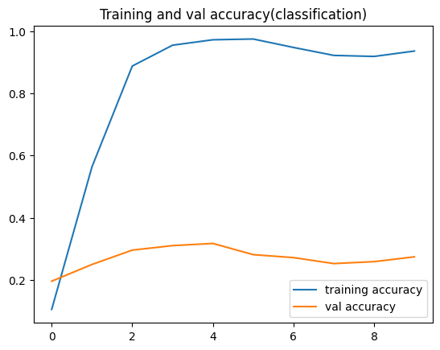

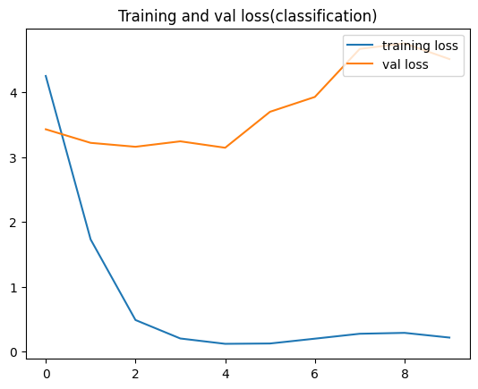

```python
# Training and validation accuracy for classification
accuracy = classification_history.history['accuracy']
val_accuracy = classification_history.history['val_accuracy']
loss = classification_history.history['loss']
val_loss = classification_history.history['val_loss']

# Get the accuracy value of each epochs
epochs = range(len(accuracy))

# plotting score
plt.plot(epochs, accuracy, label = 'training accuracy' )
plt.plot(epochs, val_accuracy, label = 'val accuracy' )
plt.title('Training and val accuracy(classification)')
plt.legend(loc = 'lower right')
plt.figure()

# plotting loss
plt.plot(epochs, loss, label = 'training loss' )
plt.plot(epochs, val_loss, label = 'val loss' )
plt.legend(loc = 'upper right')
plt.title('Training and val loss(classification)')
```

```python
# fitting the model
boundingbox_history = boundingbox_model.fit(x=train_images, y=train_boundingbox, batch_size=32, epochs=10, validation_data=(test_images,test_boundingbox))
```

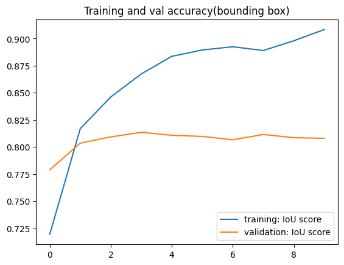

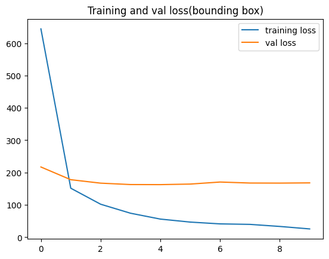

```python
# Training and validation accuracy for boundingbox
IoU_score = boundingbox_history.history['IoU']
val_IoU_score = boundingbox_history.history['val_IoU']
loss = boundingbox_history.history['loss']
val_loss = boundingbox_history.history['val_loss']

# Get the accuracy value of each epochs
epochs = range(len(IoU_score))

# plotting score
plt.plot(epochs, IoU_score, label = 'training: IoU score' )
plt.plot(epochs, val_IoU_score, label = 'validation: IoU score' )
plt.title('Training and val accuracy(bounding box)')
plt.legend(loc = 'lower right')
plt.figure()

# plotting loss
plt.plot(epochs, loss, label = 'training loss' )
plt.plot(epochs, val_loss, label = 'val loss' )
plt.legend(loc = 'upper right')
plt.title('Training and val loss(bounding box)')
plt.show()
```

#### Insights

Training accuracy is much more than testing/validation accuracy which indicates the overfit of the model

From graphs we can see, training accuracy is almost 100% but the validation accuracy is below 50%

Due to the resizeing image, the accuracy value might have reduced

Hypertuning has to be done for improving the performance of the model